# MEDB 5501, Module03

## Break #2

- What you have learned
  - Normal probabilities and quantiles
- What’s coming next
  - Assessing normality

## Assessing normality

- No variable follows a perfect normal distribution
  - But many are close
- How to assess (approximate) normality
  - Histogram
  - Boxplot
  - Normal probability plot
- Avoid formal tests of normality

## Histogram

- Peak in the middle
- Roughly symmetric
- Falls off exponentially
- Warning!! Bar width can influence your interpretation
  - Try two or more bar widths

## Sample Boxplot

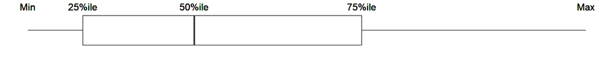

## What to look for in the boxplot

- Median halfway between 25th and 75th percentile.
- Whiskers are same size
- Whiskers not too short, not too long

## Constructing a normal probability plot, 1

- Calculate rank
- Divide by (n+1)
- Compute corresponding normal percentiles
- Compare these on a graph to the original data
- Roughly straight line implies normality

## Constructing a normal probability plot, 2

Use the rank function to assign 1 to the smallest value, 2 to the next smallest value, etc. up to n for the largest value.

```
   x r
1  7 4
2  3 2
3 23 9
4  2 1
5  5 3
6 13 6
7 11 5
8 17 7
9 19 8
```

## Constructing a normal probability plot, 3

Divide the rank by (n+1) to get evenly spaced percentages.

```
   x r pctile
1  7 4    0.4
2  3 2    0.2
3 23 9    0.9
4  2 1    0.1
5  5 3    0.3
6 13 6    0.6
7 11 5    0.5
8 17 7    0.7
9 19 8    0.8
```

## Constructing a normal probability plot, 4

Calculate percentiles from a normal distribution using the evenly spaced percentages.

```
   x r pctile          z
1  7 4    0.4 -0.2533471
2  3 2    0.2 -0.8416212
3 23 9    0.9  1.2815516
4  2 1    0.1 -1.2815516
5  5 3    0.3 -0.5244005
6 13 6    0.6  0.2533471
7 11 5    0.5  0.0000000
8 17 7    0.7  0.5244005
9 19 8    0.8  0.8416212
```

## Constructing a normal probability plot, 5

Plot the percentiles from the normal distribution to the original data. A reasonably straight line is evidence of normality.

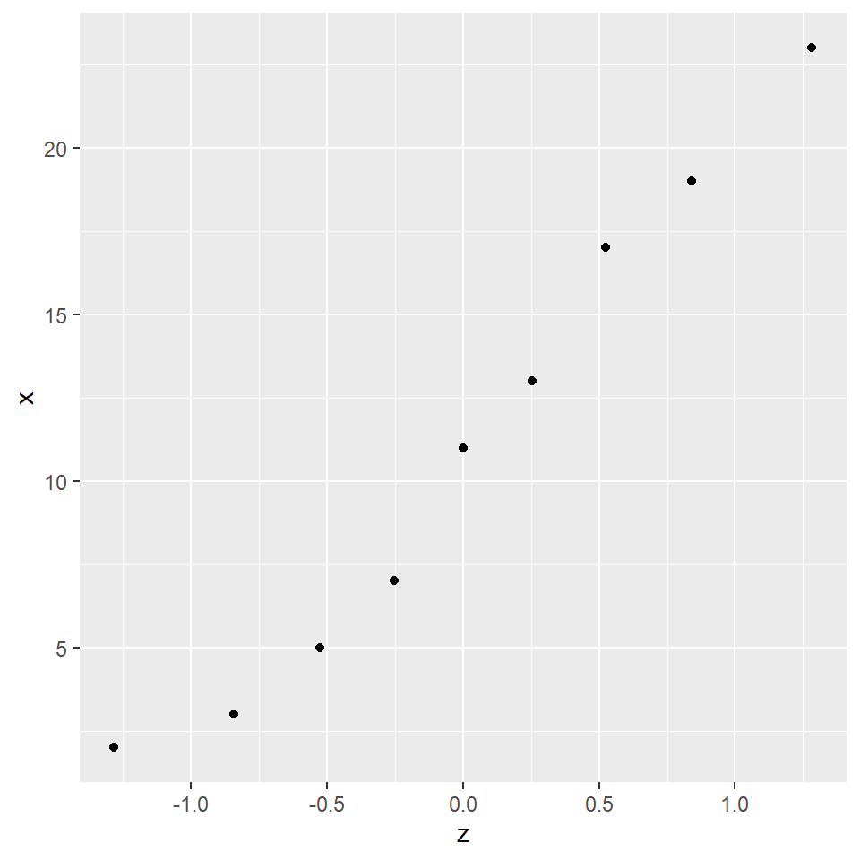

## Constructing a normal probability plot, 6

The qqnorm function will do all these steps for you automatically.

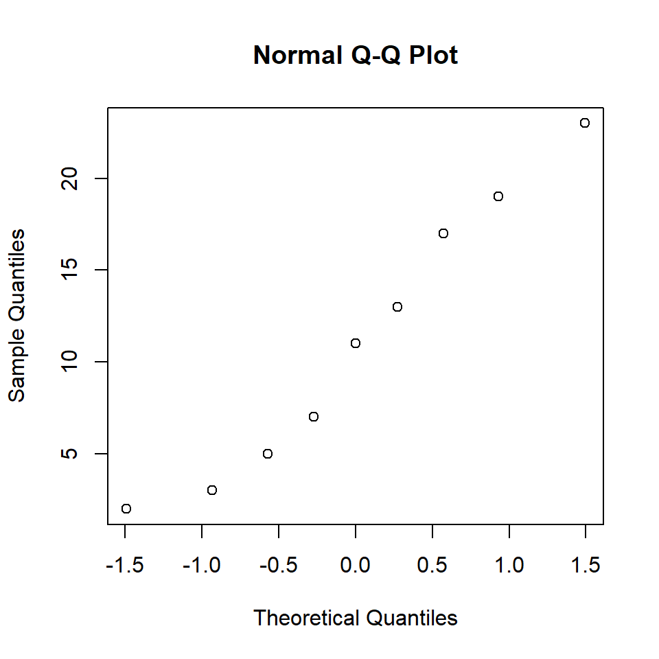

## Bimodal data, histogram

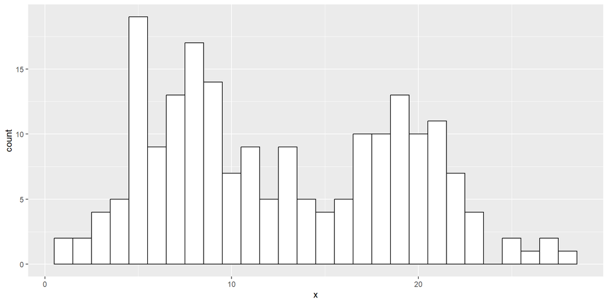

## Bimodal data, boxplot

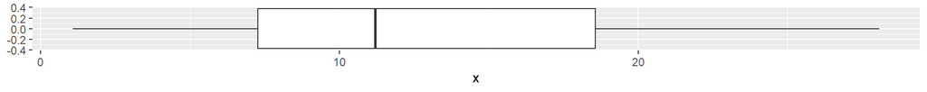

## Bimodal data, qq plot

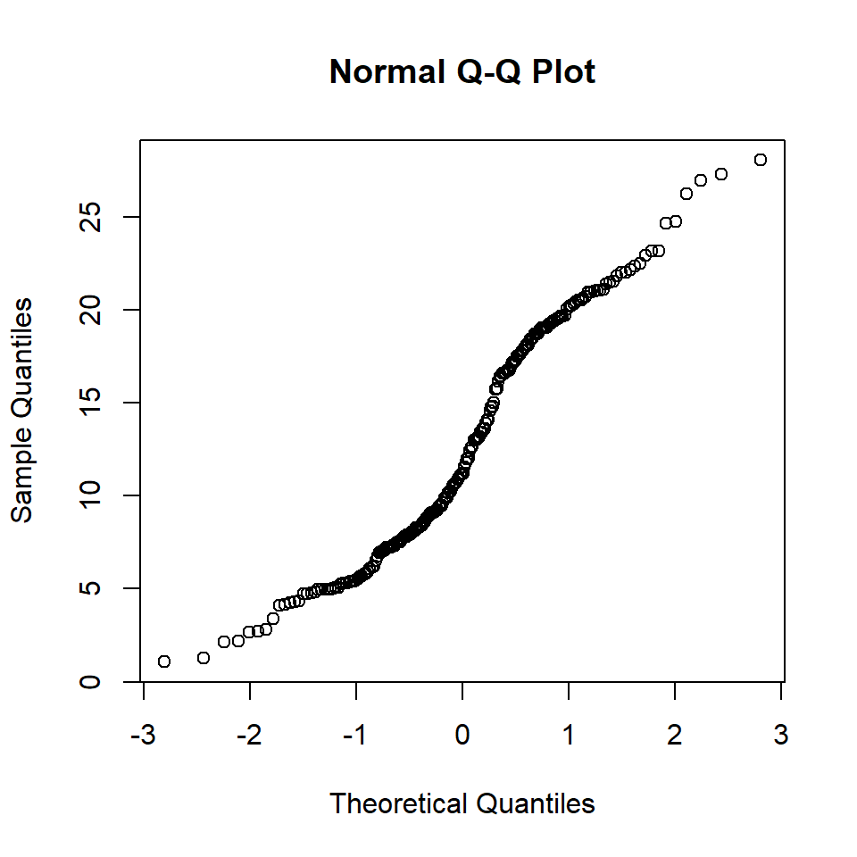

## Skewed data, histogram

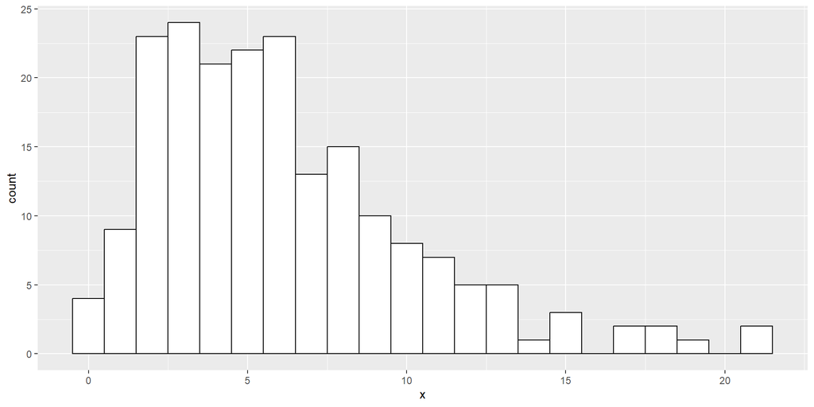

## Skewed distribution, boxplot

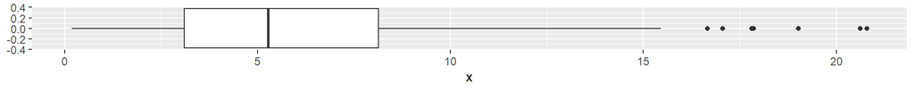

## Skewed distribution, qq plot

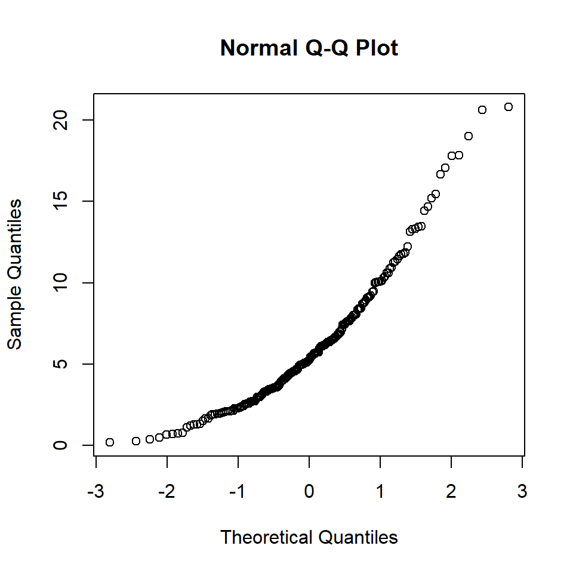

## Light-tailed data, histogram

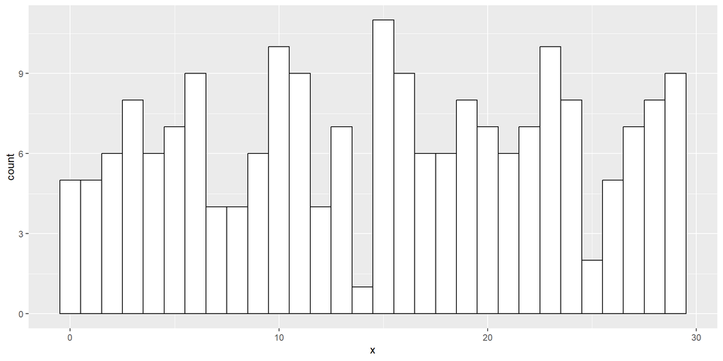